# Data Wrangling at Scale

John Mount, [Win-Vector LLC](http://www.win-vector.com/)

2018-01-25

> “[`R`](https://www.r-project.org) is its packages.”

One great example of this is: the [`sparklyr` package](https://CRAN.R-project.org/package=sparklyr), which allows `R` to work with big data. In this note we we will use the `sparklyr` package, but concentrate on another important package called [`cdata`](https://winvector.github.io/cdata/).

In the following example the table we are working with is remote. For all we know it could be distributed on a large remote data center.

Working with remote data tools can be like working with a [Waldo system](https://en.wikipedia.org/wiki/Remote_manipulator): powerful, but a touch awkward.

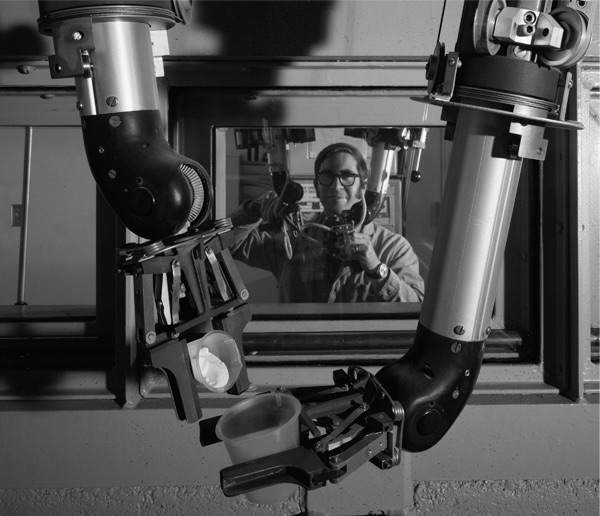

```r
library("seplyr")

d <- dplyr::tbl(sc, "starwars") %.>%
  arrange_se(., "name")
print(d)
```

```
## # Source: table<starwars> [?? x 3]
## # Database: spark_connection
## # Ordered by: name
##    name                height  mass
##    <chr>                <int> <dbl>
##  1 Ackbar                 180  83.0
##  2 Adi Gallia             184  50.0
##  3 Anakin Skywalker       188  84.0
##  4 Arvel Crynyd            NA NaN
##  5 Ayla Secura            178  55.0
##  6 BB8                     NA NaN
##  7 Bail Prestor Organa    191 NaN
##  8 Barriss Offee          166  50.0
##  9 Ben Quadinaros         163  65.0
## 10 Beru Whitesun lars     165  75.0
## # ... with more rows
```

Suppose we needed to un-pivot this data into a row oriented representation. Often big data transform steps can achieve a much higher degree of parallelization with “tall data”. With the [`cdata` package](https://winvector.github.io/cdata/) this transform is easy and performant, as we show below.

many rows, fewer columns

```r
library("cdata")

cT <- build_unpivot_control(
  nameForNewKeyColumn = "measurement",
  nameForNewValueColumn = "value",
  columnsToTakeFrom = c('height', 'mass') )
dTName <- rowrecs_to_blocks_q(
  "starwars",
  controlTable = cT,
  my_db = sc,
  columnsToCopy = "name")

str(dTName)
```

```
##  chr "mvtrq_rrakp3dqsorimj4ohzgh_0000000001"
```

```r
qlook(sc, dTName)
```

```
## table `mvtrq_rrakp3dqsorimj4ohzgh_0000000001` spark_connection spark_shell_connection DBIConnection
##  nrow: 174
##  NOTE: "obs" below is count of sample, not number of rows of data.
## 'data.frame':    10 obs. of  3 variables:
##  $ name       : chr  "Luke Skywalker" "Luke Skywalker" "C-3PO" "C-3PO" ...
##  $ measurement: chr  "height" "mass" "height" "mass" ...
##  $ value      : num  172 77 167 75 96 32 202 136 150 49
```

`cdata` can work fluidly with [`dplyr`](https://CRAN.R-project.org/package=dplyr).

However, `cdata` does not require `dplyr`.

```r
dT <- dplyr::tbl(sc, dTName)

dT %.>%
  arrange_se(., c("name", "measurement")) %.>%
  head(., n = 12) %.>%
  knitr::kable(.)
```

| name | measurement | value |
| --- | --- | --- |
| Ackbar | height | 180 |
| Ackbar | mass | 83 |
| Adi Gallia | height | 184 |
| Adi Gallia | mass | 50 |
| Anakin Skywalker | height | 188 |
| Anakin Skywalker | mass | 84 |
| Arvel Crynyd | height | NaN |
| Arvel Crynyd | mass | NaN |
| Ayla Secura | height | 178 |
| Ayla Secura | mass | 55 |
| BB8 | height | NaN |
| BB8 | mass | NaN |

`cdata` is itself is based on `SQL` aggregations, using the [`DBI` package](https://CRAN.R-project.org/package=DBI).

This is why “BB8”’s `NA` (likely represented on the remote system as a `NULL`) gets changed to a `NaN`.

The important thing is: the data stays remote, all operations are performed on the remote big data system, possibly in parallel.

`class(dT)`: tbl_spark, tbl_sql, tbl_lazy, tbl

Note: the [`tidyr` package](https://CRAN.R-project.org/package=tidyr) does not currently (0.7.2) work with remote data: `tidyr::gather(d, key=measurement, value=value, mass, height)` Error in gather.default(d, key = measurement, value = value, mass, height): object ‘height’ not found .

The `cdata` arguments are deliberately verbose. This is because at some point you may have to read your own code, and it is best to be reminded about the role of each function argument at that time.

Notice `cdata` takes *names* of tables as arguments and also returns *names* of tables (not values or `dplyr::tbl()` handles). This is why we show the explicit use of `dplyr::tbl()` to produce remote data handles in this example.

Basing storage on names instead of handles means: for production code you need tools to help manage table lifetime. `cdata::makeTempNameGenerator()` is supplied for that purpose. As in-memory data doesn’t have representation names in the same sense remote data does, `cdata` supplies in-memory value to value functions: `rowrecs_to_blocks()`, `buildPivotControlTableD()`, and `blocks_to_rowrecs()`.

The reverse operation (often called pivoting) is also easy (and in fact shares the same control structures).

```r
dL <- blocks_to_rowrecs_q(
  dTName,
  keyColumns = "name",
  controlTable = cT,
  my_db = sc ) %.>%
  dplyr::tbl(sc, .)

dL %.>%
  arrange_se(., "name") %.>%
  head(., n = 6) %.>%
  knitr::kable(.)
```

| name | height | mass |
| --- | --- | --- |
| Ackbar | 180 | 83 |
| Adi Gallia | 184 | 50 |
| Anakin Skywalker | 188 | 84 |
| Arvel Crynyd | NaN | NaN |
| Ayla Secura | 178 | 55 |
| BB8 | NaN | NaN |

More on these sort of transforms can be found in the following notes:

- [Theory of coordinatized data](http://winvector.github.io/FluidData/RowsAndColumns.html)
- [Fluid data reshaping with cdata](http://winvector.github.io/FluidData/FluidDataReshapingWithCdata.html)
- [Fluid data transforms](http://winvector.github.io/FluidData/FluidData.html)